# CyteType Report

CyteType Report

## CyteType Report

View Online

Completed

November 12, 2025 at 4:06 PM

TITLE: scRNA-seq analysis of axolotl limb regeneration, all primary cells

RUN_LABEL: first_pass_annotation

EXPERIMENT_NAME: inDrops_axo

DOI: https://doi.org/10.1038/s41467-018-07604-0

GEO_ACCESSION: GSE121737

### Dataset Context

The study focuses on the Mexican axolotl (Ambystoma mexicanum), a model organism renowned for its regenerative capabilities, specifically examining immune and non-immune cells during a time course of limb regeneration. The primary tissues involved include skeletal muscle, which normally comprises multinucleated myofibers and satellite cells essential for contraction and repair; skin, encompassing the epidermis with keratinocytes and the dermis with fibroblasts and extracellular matrix components; and connective tissue, primarily consisting of fibroblasts and collagen-rich stroma that provide structural support. These tissues are in regenerating, proliferative, and stressed states, reflecting the dynamic cellular processes of dedifferentiation, proliferation, and redifferentiation characteristic of axolotl limb regrowth, potentially influenced by metabolic activity, stress responses, and immune modulation as inferred from gene expression patterns indicative of translation, mitochondrial function, and stress proteins.

### Tissue Composition Assessment

The dataset provides a comprehensive representation of immune cells, connective tissue fibroblasts, epithelial cells, endothelial cells, and neural precursors expected in axolotl limb regeneration, but lacks skeletal muscle components, with notable regenerative plasticity in several lineages.

### Notable Findings

- Erythroid progenitor cells (cluster 1) in tissue context, suggesting hematopoietic involvement or stress-induced erythropoiesis during regeneration.
- Fibroblasts with keratin co-expression (clusters 3, 6, 11), indicating epithelial-mesenchymal plasticity characteristic of blastema formation.
- Mixed epithelial-mesenchymal epithelial cells (cluster 7) and stress-adapted progenitors (cluster 8), highlighting dedifferentiation processes.
- Diverse macrophage subpopulations (clusters 5, 10, 12) with phagocytic and complement roles, underscoring immune modulation in regeneration.
- Schwann cell precursors (cluster 16), pointing to neural contributions to limb regrowth.

### Missing Cell Types

- Skeletal muscle myofibers and satellite cells, likely missing due to dedifferentiation into blastema-like states or low representation in proliferative regenerating tissue.
- Classical keratinocytes without mesenchymal markers, possibly underrepresented as epidermal cells undergo stress adaptations or EMT during regeneration.

1

### Erythroid Progenitor Cell

HEMGN-positive, ALAS2-expressing, GATA1-independent erythroid progenitor cell with active heme biosynthesis and atypical GRM5/ENG co-expression

Confidence: High

CELL ONTOLOGY TERM

[erythroid progenitor cell (CL_0000038)](http://purl.obolibrary.org/obo/CL_0000038)

CELL STATE differentiating

ORIGINAL LABEL 0

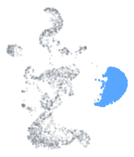

2

### Epithelial Cell (stratified, keratin-lacking)

EPCAM-positive, desmosome-rich epithelial cell with stratified epithelial transcription factor signature but lacking keratin expression

Confidence: High

CELL ONTOLOGY TERM

[stratified epithelial cell (CL_0000079)](http://purl.obolibrary.org/obo/CL_0000079)

CELL STATE homeostatic

ORIGINAL LABEL 1

FUNCTIONALLY SIMILAR TO

Epithelial Cell (mesenchymal-mixed, regenerating) (7)

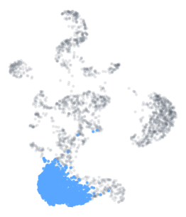

3

### KRT8+ Connective Tissue Fibroblast (blastema)

COL1A1/COL3A1-high, KRT8/KRT18-positive regenerative connective tissue fibroblast with active ECM remodeling and developmental signaling during limb blastema formation

Confidence: High

CELL ONTOLOGY TERM

[fibroblast of areolar connective tissue (CL_1000303)](http://purl.obolibrary.org/obo/CL_1000303)

CELL STATE regenerative, proliferative

ORIGINAL LABEL 2

FUNCTIONALLY SIMILAR TO

Fibroblast (proliferating) (6)Dermal Fibroblast (LUM+) (11)

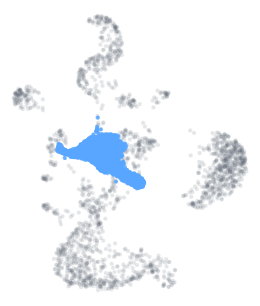

4

### Epithelial Cell

EPCAM-positive, E-cadherin-expressing epithelial cell with robust desmosomal junctions and tight junction complexes

Confidence: High

CELL ONTOLOGY TERM

[epithelial cell (CL_0000066)](http://purl.obolibrary.org/obo/CL_0000066)

CELL STATE secretory, adhesion-active

ORIGINAL LABEL 3

DEVELOPMENTALLY RELATED TO

B Cell (differentiates_from)

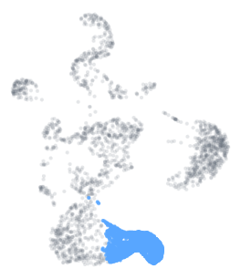

5

### Tissue-Resident Macrophage (AIF1+/CSF1R+)

AIF1+/CSF1R+/C1Q+ phagocytic tissue-resident macrophage with complement-mediated immune surveillance function

Confidence: High

CELL ONTOLOGY TERM

[tissue-resident macrophage (CL_0000864)](http://purl.obolibrary.org/obo/CL_0000864)

CELL STATE activated

ORIGINAL LABEL 4

FUNCTIONALLY SIMILAR TO

Phagocytic Macrophage (LYZ+ non-inflammatory) (10)Macrophage (C1Q+ lysosomal) (12)

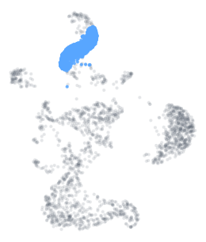

6

### Fibroblast (proliferating)

COL1A1/COL1A2/COL3A1-high, KRT8-positive regenerative fibroblast with heterogeneous subpopulations including proliferating and chondrogenic-primed cells

Confidence: High

⚠ HETEROGENEOUS

CELL ONTOLOGY TERM

[fibroblast (CL_0000057)](http://purl.obolibrary.org/obo/CL_0000057)

CELL STATE heterogeneous: proliferating, chondrogenic-primed

ORIGINAL LABEL 5

FUNCTIONALLY SIMILAR TO

KRT8+ Connective Tissue Fibroblast (blastema) (3)Dermal Fibroblast (LUM+) (11)

DEVELOPMENTALLY RELATED TO

Epithelial Cell (differentiates_from)

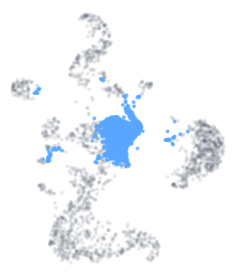

7

### Epithelial Cell (mesenchymal-mixed, regenerating)

EPCAM-positive, desmoplakin-expressing epithelial cell with mixed epithelial-mesenchymal characteristics during limb regeneration

Confidence: High

CELL ONTOLOGY TERM

[epithelial cell (CL_0000066)](http://purl.obolibrary.org/obo/CL_0000066)

CELL STATE differentiated

ORIGINAL LABEL 6

FUNCTIONALLY SIMILAR TO

Epithelial Cell (stratified, keratin-lacking) (2)

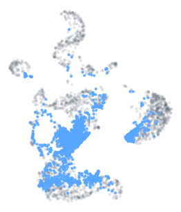

8

### Epithelial Cell

TP63-positive, EPCAM-expressing, S100-rich epithelial cell with transglutaminase activity, basement membrane attachment, and elevated antioxidant response

Confidence: High

CELL ONTOLOGY TERM

[basal cell (CL_0000646)](http://purl.obolibrary.org/obo/CL_0000646)

CELL STATE stress-adapted, non-proliferative, metabolically active

ORIGINAL LABEL 7

DEVELOPMENTALLY RELATED TO

Basal Keratinocyte (differentiates_to)Fibroblast (proliferating) (differentiates_to)

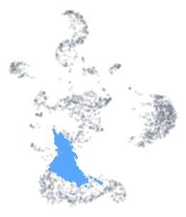

9

### CD8+ T Cell

CD8+ cytotoxic T lymphocyte with strong T cell receptor signaling and cytotoxic effector molecules

Confidence: Moderate

⚠ HETEROGENEOUS

CELL ONTOLOGY TERM

[CD8-positive, alpha-beta cytotoxic T cell (CL_0000794)](http://purl.obolibrary.org/obo/CL_0000794)

CELL STATE cytotoxic effector

ORIGINAL LABEL 8

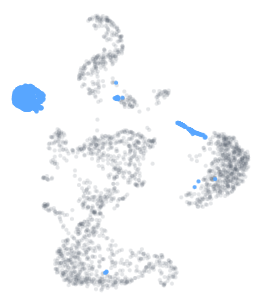

10

### Phagocytic Macrophage (LYZ+ non-inflammatory)

LYZ-positive, AIF1-positive non-inflammatory phagocytic macrophage with complement activation and debris clearance specialization

Confidence: High

CELL ONTOLOGY TERM

[tissue-resident macrophage (CL_0000864)](http://purl.obolibrary.org/obo/CL_0000864)

CELL STATE phagocytic, non-inflammatory

ORIGINAL LABEL 9

FUNCTIONALLY SIMILAR TO

Tissue-Resident Macrophage (AIF1+/CSF1R+) (5)Macrophage (C1Q+ lysosomal) (12)

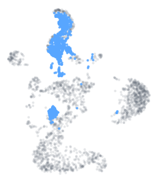

11

### Dermal Fibroblast (LUM+)

COL1A1/COL3A1-high, LUM-positive dermal fibroblast with KRT8/KRT18 co-expression reflecting regeneration-associated transcriptional plasticity

Confidence: High

CELL ONTOLOGY TERM

[fibroblast (CL_0000057)](http://purl.obolibrary.org/obo/CL_0000057)

CELL STATE ECM-producing, regeneration-associated with transcriptional plasticity

ORIGINAL LABEL 10

FUNCTIONALLY SIMILAR TO

KRT8+ Connective Tissue Fibroblast (blastema) (3)Fibroblast (proliferating) (6)

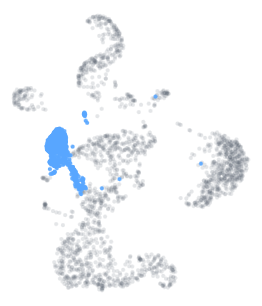

12

### Macrophage (C1Q+ lysosomal)

C1Q-expressing phagocytic macrophage with lysosomal activity

Confidence: High

CELL ONTOLOGY TERM

[TREM2-positive macrophage (CL_4047053)](http://purl.obolibrary.org/obo/CL_4047053)

CELL STATE activated

ORIGINAL LABEL 11

FUNCTIONALLY SIMILAR TO

Tissue-Resident Macrophage (AIF1+/CSF1R+) (5)Phagocytic Macrophage (LYZ+ non-inflammatory) (10)

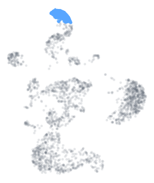

13

### B Cell

CD79A/CD79B-positive B cell with IGLL1 expression and immunoglobulin production

Confidence: High

CELL ONTOLOGY TERM

[B cell (CL_0000236)](http://purl.obolibrary.org/obo/CL_0000236)

CELL STATE activated

ORIGINAL LABEL 12

DEVELOPMENTALLY RELATED TO

Epithelial Cell (differentiates_to)

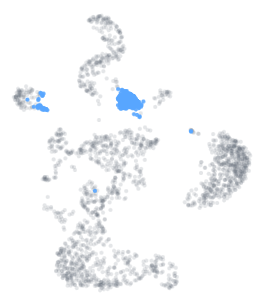

14

### Vascular Endothelial Cell

VWF-positive, PLVAP-expressing angiogenic vascular endothelial cell with LYVE1+ subpopulation during limb regeneration

Confidence: High

⚠ HETEROGENEOUS

CELL ONTOLOGY TERM

[endothelial stalk cell (CL_0002671)](http://purl.obolibrary.org/obo/CL_0002671)

CELL STATE angiogenic

ORIGINAL LABEL 13

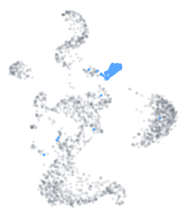

15

### Basal Keratinocyte

COL17A1-positive, ITGB4-expressing basal keratinocyte with extensive collagen production and basement membrane assembly features

Confidence: High

CELL ONTOLOGY TERM

[basal cell of epidermis (CL_0002187)](http://purl.obolibrary.org/obo/CL_0002187)

CELL STATE regenerative

ORIGINAL LABEL 14

DEVELOPMENTALLY RELATED TO

Epithelial Cell (differentiates_from)

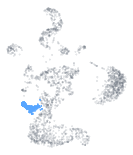

16

### Schwann Cell Precursor

SOX10-positive, NGFR-expressing neural crest-derived Schwann cell precursor with basement membrane interaction and proliferative characteristics

Confidence: High

⚠ HETEROGENEOUS

CELL ONTOLOGY TERM

[Schwann cell precursor (CL_0002375)](http://purl.obolibrary.org/obo/CL_0002375)

CELL STATE precursor, proliferating

ORIGINAL LABEL 15

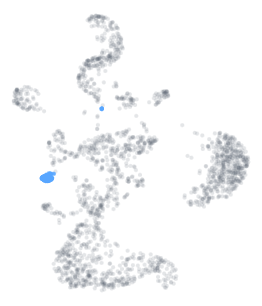